# Enrichment analysis

During classification, we used many subgroups of genes to classify the mutations. There were some performing better, some performing worse. We would like to understand whether these genes change significantly between mutated and non mutated cells. To do this, we will perform enrichment analysis and the very famous method GSEA[1].

We will test the following group of genes obtained during the respective classification of CCLE and TGCA:

1. Target genes of TP53;
2. 100 most relevant genes in classification chosen from TP53 targets;
3. 100 most relevant genes in classification chosen from the whole gene corpus;

NOTE: The 100 most relevant genes were chosen based on Spearman correlation coefficient [2] between expression and binary mutation type.

## GSEA

**Ingredients**:

1. Expression of samples belonging to two classes
2. Gene set **S**
3. Ranking method between expression and class distinction **r**

**Intermediate Step**:  
We compute the correlation **r** between each gene array, expression of the gene across samples, and the mutation array. Then, we rank the gene based on **r** to have a ranked list **L**.

**Goal**:  
Understand if the gene set **S** is randomly distributed around **L** or it is found at the top or at the bottom.

**Methods**:  
GSEA computes an enrichment score **ES** which reflect the degree at which the set **S** is overrepresented at the extremes (top or bottom). In order to compute that we will use a Kolmogorov-Smirnov statistics, which measure maximum discrepancy between two cumulative distributions functions. In more simple words, we keep an array of the length of the whole gene corpus, which will keep a cumulative sum. It will be initiated at all zeros. Then, we iterate from the most correlated gene to the least, two possible cases can occur:

1. The gene **g** is the gene set **S**, then: $$ RES[k] = RES[k-1] + \frac{|r(g)|^p}{|S|} $$
2. The gene **g** is not in the gene set **S**, then: $$ RES[k] = RES[k-1] - \frac{1}{N -|S|} $$ Where, N is the number of genes and |S| is the cardinality of the gene set and p tells us how much we want to weight the correlation coefficient. Our **ES** will be the max of the cumulative sum, so the maximum deviation, the biggest period in which my function increased.

**Discussion** On one hand, if the set **S** is well concentrated on one part of the ranked list, we will keep summing and get an higher value. On the other hand, if the set is randomly distributed, we keep summing and subtracting without reaching a substantial value.

## Imports

```python
import numpy as np
import pandas as pd
import matplotlib.pyplot as plt
import seaborn as sns
from scipy.stats import spearmanr
from sklearn.preprocessing import StandardScaler
import gseapy
```

```python
def standard(df):
    """
    Standardize value.

    Args:
        df (pandas.dataframe): dataframe.

    Returns:
        pandas.dataframe: Data after standardization.

    """
    dt = df.copy()
    #dt = dt.astype("float64")
    # function for data standardization
    gene_names = dt.columns
    cell_names = dt.index

    scaler = StandardScaler(with_mean=False)
    scaler.fit(dt)
    dt = scaler.transform(dt)

    dt = pd.DataFrame(dt)
    dt.columns = gene_names
    dt.index = cell_names

    return(dt)
```

## CCLE

```python
mRNA_ccle = pd.read_csv('batch_corrected_CCLE.csv')
mRNA_ccle.set_index('Hugo_Symbol',inplace=True)
mRNA_ccle.head()
```

| Hugo_Symbol | PANC1005_PANCREAS_cellline_ccle_broad | U251MG_CENTRAL_NERVOUS_SYSTEM_cellline_ccle_broad | HMCB_SKIN_cellline_ccle_broad | BCPAP_THYROID_cellline_ccle_broad | SKCO1_LARGE_INTESTINE_cellline_ccle_broad | KMBC2_URINARY_TRACT_cellline_ccle_broad | HH_HAEMATOPOIETIC_AND_LYMPHOID_TISSUE_cellline_ccle_broad | JHH1_LIVER_cellline_ccle_broad | MC116_HAEMATOPOIETIC_AND_LYMPHOID_TISSUE_cellline_ccle_broad | LS180_LARGE_INTESTINE_cellline_ccle_broad | ... | OPM1_HAEMATOPOIETIC_AND_LYMPHOID_TISSUE_ccle_broad_2019 | OCIAML3_HAEMATOPOIETIC_AND_LYMPHOID_TISSUE_ccle_broad_2019 | A549_LUNG_ccle_broad_2019 | ALLSIL_HAEMATOPOIETIC_AND_LYMPHOID_TISSUE_ccle_broad_2019 | CHLA32_BONE_ccle_broad_2019 | NCIH3255_LUNG_ccle_broad_2019 | P12ICHIKAWA_HAEMATOPOIETIC_AND_LYMPHOID_TISSUE_ccle_broad_2019 | R262_CENTRAL_NERVOUS_SYSTEM_ccle_broad_2019 | KYSE510_OESOPHAGUS_ccle_broad_2019 | PANC0403_PANCREAS_ccle_broad_2019 |
| --- | --- | --- | --- | --- | --- | --- | --- | --- | --- | --- | --- | --- | --- | --- | --- | --- | --- | --- | --- | --- | --- |
| GABRR1 | -1.388582 | -1.245921 | -1.205008 | -1.287129 | -1.195400 | -1.165759 | -1.197755 | -1.138087 | -1.161399 | -1.187963 | ... | -1.053447 | -1.086937 | -1.165183 | -1.027403 | -1.220121 | -1.290405 | -1.093890 | 0.329007 | -0.841031 | -1.186375 |
| PTPN3 | 0.465719 | -0.982662 | -0.908150 | 0.356517 | 0.089309 | 0.341322 | 0.785169 | -0.110635 | -0.815452 | 0.700377 | ... | -0.288635 | -0.834755 | 0.230819 | 0.695714 | -0.441679 | 0.545314 | 0.662221 | 0.414095 | 0.307346 | 0.427656 |
| VASH2 | -0.869893 | -1.058471 | 0.169306 | -0.859492 | -0.600480 | -0.576364 | 0.702850 | -0.011726 | -0.967886 | 0.017922 | ... | -0.820041 | -0.804398 | -0.339785 | -0.869120 | 1.356037 | -0.733344 | 0.131600 | -0.520881 | -0.759736 | -0.891017 |
| SSH3 | 0.656943 | 0.320564 | 0.175438 | 0.821896 | 0.861666 | 1.617019 | -0.222234 | 1.030305 | -0.108737 | 0.594084 | ... | -0.523972 | -0.206837 | 0.164057 | -0.333776 | -0.786023 | 1.235918 | -0.527724 | 0.386959 | 1.239264 | 0.894921 |
| ZNF567 | 0.311808 | 0.174420 | 0.176398 | 0.011369 | 0.044752 | 0.227758 | -0.184438 | 0.184552 | 0.187226 | 0.202067 | ... | 0.401063 | -0.059239 | 0.494016 | 0.355861 | 0.403120 | -0.054781 | 0.405058 | 0.573031 | -0.342589 | -0.008417 |

5 rows × 2045 columns

```python
mut_ccle = pd.read_csv('mutations_CCLE.csv')
mut_ccle.set_index('Unnamed: 0',inplace=True)
# 0 if WT 1 if mutated
mut_ccle['Variant_Type'] = mut_ccle['Variant_Type'].apply(lambda x: 0 if x == 'WT' else 1)
mut_ccle = mut_ccle['Variant_Type']
mut_ccle = mut_ccle[mRNA_ccle.columns]
mut_ccle
```

```
PANC1005_PANCREAS_cellline_ccle_broad                             1
U251MG_CENTRAL_NERVOUS_SYSTEM_cellline_ccle_broad                 0
HMCB_SKIN_cellline_ccle_broad                                     0
BCPAP_THYROID_cellline_ccle_broad                                 1
SKCO1_LARGE_INTESTINE_cellline_ccle_broad                         0
                                                                 ..
NCIH3255_LUNG_ccle_broad_2019                                     1
P12ICHIKAWA_HAEMATOPOIETIC_AND_LYMPHOID_TISSUE_ccle_broad_2019    1
R262_CENTRAL_NERVOUS_SYSTEM_ccle_broad_2019                       1
KYSE510_OESOPHAGUS_ccle_broad_2019                                1
PANC0403_PANCREAS_ccle_broad_2019                                 1
Name: Variant_Type, Length: 2045, dtype: int64
```

```python
spearman_abs_series = mRNA_ccle.apply(
    lambda row: abs(spearmanr(row.values, mut_ccle.values)[0]),
    axis=1
)
spearman_abs_series = spearman_abs_series.sort_values(ascending=False)
spearman_abs_series
```

```
Hugo_Symbol
RPS27L    0.482295
CDKN1A    0.431091
MDM2      0.422407
ZMAT3     0.416236
BAX       0.392027
            ...
PANX1     0.000049
RNF167    0.000048
RIMKLA    0.000039
CHID1     0.000039
VWA5B2    0.000015
Length: 13867, dtype: float64
```

### Targets of TP53

Targets took from the p53 database [3]

```python
with open('/home/3173616/ML_lab/targets_tp53.txt', 'r') as file:
    tp53_targets = [target.strip()[1:len(target.strip())-1] for target in file.read().split(',')]
print('Total number of target:', len(tp53_targets))
print('Total number of duplicates:', len(tp53_targets)-len(set(tp53_targets)))
```

```
Total number of target: 343
Total number of duplicates: 0
```

```python
# Take just the targets in the set
helper = []
for target in tp53_targets:
    if target not in spearman_abs_series.index:
        helper.append(target)

for h in helper:
    tp53_targets.remove(h)
```

```
Enrichment Score (ES): 0.42827404412677894
Normalized Enrichment Score (NES): 1.440237410869872
Nominal p-value: 0.0
```

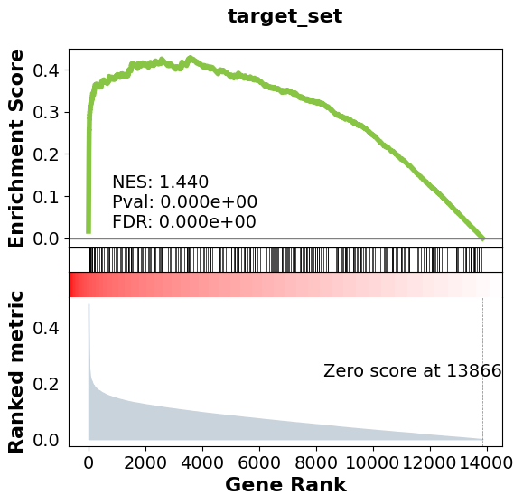

```python
res = gseapy.prerank(
    rnk=spearman_abs_series,
    gene_sets= {"target_set": tp53_targets},
    processes=4,
    permutation_num=1000,  # or 100 for speed
    seed=42,
    outdir=None,  # avoids saving files
    verbose=True
)

result_df = res.res2d

print(f"Enrichment Score (ES): {result_df['ES'][0]}")
print(f"Normalized Enrichment Score (NES): {result_df['NES'][0]}")
print(f"Nominal p-value: {result_df['NOM p-val'][0]}")

gseapy.plot.gseaplot(
    rank_metric=spearman_abs_series,
    term='target_set',
    **res.results['target_set']
);
```

### Top 100 starting from targets

```python
top_100_targets = ['RPS27L', 'CDKN1A', 'MDM2', 'ZMAT3', 'BAX', 'XPC', 'RRM2B', 'DDB2', 'FDXR', 'AEN', 'SESN1', 'PHLDA3',
                    'ACTA2', 'CCNG1', 'POLH', 'SPATA18', 'TNFRSF10B', 'WDR63', 'DCP1B', 'FAS', 'IKBIP', 'DRAM1', 'ASCC3',
                    'FBXO22', 'BBC3', 'PPM1D', 'CYFIP2', 'PLK3', 'PHPT1', 'ASTN2', 'ZNF561', 'VWCE', 'TRIM22', 'TP53INP1',
                    'SFN', 'APOBEC3C', 'MFAP3L', 'SESN2', 'GDF15', 'GBE1', 'SERPINB5', 'PCBP4', 'BLCAP', 'SYTL1', 'DYRK3',
                    'VCAN', 'BTG2', 'CES2', 'CPEB2', 'HHAT', 'PLLP', 'SLC12A4', 'RGL1', 'PTP4A1', 'EPN3', 'ZNF79', 'TP53I3',
                    'REV3L', 'TM7SF3', 'HES1', 'FAM84B', 'TRIM5', 'C17orf89', 'LPXN', 'ANKRA2', 'ZNF488', 'DDR1', 'NLRP1', 'TSPAN11',
                 'FAM13C', 'AMZ2', 'RETSAT', 'FAM196A', 'SCN2A', 'KRT15', 'NINJ1', 'TRIM32', 'ENPP2', 'PTAFR', 'NKAIN4', 'PTPRU',
                  'S100A2', 'SCN4B', 'LRP1', 'PCLO', 'ORAI3', 'SLC44A5', 'PDE4C', 'SLC4A11', 'CLDN1', 'TNFRSF10A', 'CROT', 'SULF2',
                   'PLXNB2', 'TRIP6', 'PARD6G', 'CSF1', 'MON2', 'GPR87', 'TSKU']
# Take just the targets in the set
helper = []
for target in top_100_targets:
    if target not in spearman_abs_series.index:
        helper.append(target)

for h in helper:
    top_100_targets.remove(h)
```

```
Enrichment Score (ES): 0.7440591165965527
Normalized Enrichment Score (NES): 2.372740282445966
Nominal p-value: 0.0
```

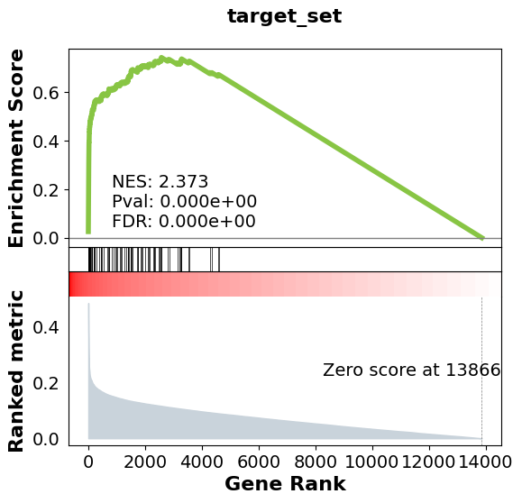

```python
res = gseapy.prerank(
    rnk=spearman_abs_series,
    gene_sets= {"target_set": top_100_targets},
    processes=4,
    permutation_num=1000,
    seed=42,
    outdir=None,
    verbose=True
)

result_df = res.res2d

print(f"Enrichment Score (ES): {result_df['ES'][0]}")
print(f"Normalized Enrichment Score (NES): {result_df['NES'][0]}")
print(f"Nominal p-value: {result_df['NOM p-val'][0]}")

gseapy.plot.gseaplot(
    rank_metric=spearman_abs_series,
    term='target_set',
    **res.results['target_set']
);
```

### Top 100 starting from the whole corpus

```python
top_100_all = ['RPS27L', 'CDKN1A', 'MDM2', 'ZMAT3', 'BAX', 'XPC', 'RRM2B', 'DDB2', 'FDXR', 'AEN', 'SESN1', 'PHLDA3',
                'ACTA2', 'CCNG1', 'POLH', 'SPATA18', 'C12orf5', 'TNFRSF10B', 'RPL22L1', 'WDR63', 'DCP1B', 'IFFO1', 'FAS', 'CYGB', 'PKD2',
                'RCE1', 'IKBIP', 'DRAM1', 'ASCC3', 'EPCAM', 'CDKN2A', 'DDR2', 'FBXO22', 'CGN', 'ZNF25', 'BBC3', 'PPM1D', 'NSUN7', 'SPINT2',
                'MARK2', 'MTMR6', 'ASPA', 'SPINT1', 'TXNDC15', 'ZNRF2', 'MPG', 'STON2', 'PLS1', 'CYFIP2', 'TMEM182', 'PLK3', 'TMEM216', 'EXPH5',
                'PTGIR', 'CNKSR1', 'PHPT1', 'TPX2', 'ASTN2', 'OVOL2', 'SENP2', 'PPL', 'TNFAIP6', 'CLDN7', 'CHMP4C', 'FUT1', 'MAL2', 'WDR53',
               'NUP155', 'GALNT3', 'ST14', 'STX2', 'KDM2A', 'PLEKHA7', 'SACS', 'ESRP2', 'CLDN4', 'CHKA', 'SGCD', 'TACSTD2', 'SIX4', 'LAMP3',
                'CDH3', 'MAP3K12', 'ZNF561', 'GCLC', 'POLK', 'MYOZ2', 'CLDN3', 'LMF1', 'C8orf58', 'PPP3CC', 'NET1', 'MMAA', 'ZEB2', 'GRHL1',
                'GPSM2', 'TRPV2', 'FOXA1', 'RAB25', 'ESRP1']

# Take just the targets in the set
helper = []
for target in top_100_all:
    if target not in spearman_abs_series.index:
        helper.append(target)

for h in helper:
    top_100_all.remove(h)
```

```
Enrichment Score (ES): 0.9949153773516374
Normalized Enrichment Score (NES): 3.1705617318877852
Nominal p-value: 0.0
```

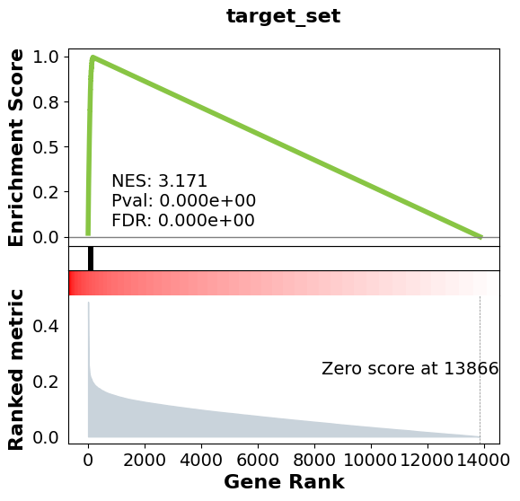

```python
res = gseapy.prerank(
    rnk=spearman_abs_series,
    gene_sets= {"target_set": top_100_all},
    processes=4,
    permutation_num=1000,
    seed=42,
    outdir=None,
    verbose=True
)

result_df = res.res2d

print(f"Enrichment Score (ES): {result_df['ES'][0]}")
print(f"Normalized Enrichment Score (NES): {result_df['NES'][0]}")
print(f"Nominal p-value: {result_df['NOM p-val'][0]}")

gseapy.plot.gseaplot(
    rank_metric=spearman_abs_series,
    term='target_set',
    **res.results['target_set']
);
```

## TGCA

```python
mRNA_tcga = pd.read_csv('Final_mRNA_data.csv')
mRNA_tcga.set_index('Hugo_Symbol',inplace=True)
mRNA_tcga = standard(np.log1p(mRNA_tcga))
```

```python
mut_tcga = pd.read_csv('Final_mutation_data.csv')
mut_tcga.set_index('SAMPLE_ID',inplace=True)
# 0 if WT 1 if mutated
mut_tcga['Variant_Type'] = mut_tcga['Variant_Type'].apply(lambda x: 0 if x == 'WT' else 1)
mut_tcga = mut_tcga['Variant_Type']
mut_tcga = mut_tcga[mRNA_tcga.columns]
mut_tcga
```

```
TCGA-CA-6719-01    1
TCGA-A8-A08R-01    1
TCGA-AA-3952-01    0
TCGA-EW-A1PH-01    1
TCGA-86-6562-01    0
                  ..
TCGA-ER-A19G-06    0
TCGA-BJ-A290-01    0
TCGA-EM-A1YE-01    0
TCGA-61-1918-01    0
TCGA-49-4486-01    0
Name: Variant_Type, Length: 3529, dtype: int64
```

```python
spearman_abs_series_tcga = mRNA_tcga.apply(
    lambda row: abs(spearmanr(row.values, mut_tcga.values)[0]),
    axis=1
)
spearman_abs_series_tcga = spearman_abs_series_tcga.sort_values(ascending=False)
spearman_abs_series_tcga
```

```
Hugo_Symbol
EDA2R     0.529271
TPX2      0.518584
CDCA8     0.518251
TTK       0.517845
FAM54A    0.514593
            ...
TCEAL7    0.000052
MEOX1     0.000035
CADM4     0.000021
NBPF4     0.000003
LHX6      0.000001
Length: 17450, dtype: float64
```

### Targets of TP53

```python
with open('/home/3173616/ML_lab/targets_tp53.txt', 'r') as file:
    tp53_targets = [target.strip()[1:len(target.strip())-1] for target in file.read().split(',')]
print('Total number of target:', len(tp53_targets))
print('Total number of duplicates:', len(tp53_targets)-len(set(tp53_targets)))

# Take just the targets in the set
helper = []
for target in tp53_targets:
    if target not in spearman_abs_series_tcga.index:
        helper.append(target)

for h in helper:
    tp53_targets.remove(h)
```

```
Total number of target: 343
Total number of duplicates: 0
```

```
Enrichment Score (ES): 0.32123178174376715
Normalized Enrichment Score (NES): 1.019212486214764
Nominal p-value: 0.389
```

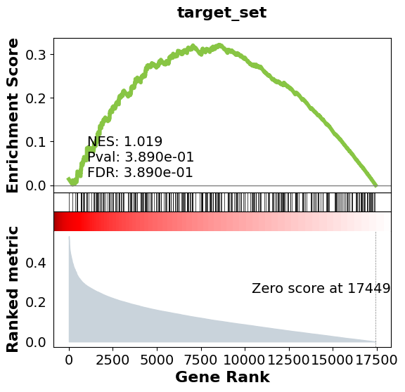

```python
res = gseapy.prerank(
    rnk=spearman_abs_series_tcga,
    gene_sets= {"target_set": tp53_targets},
    processes=4,
    permutation_num=1000,
    seed=42,
    outdir=None,
    verbose=True
)

result_df = res.res2d

print(f"Enrichment Score (ES): {result_df['ES'][0]}")
print(f"Normalized Enrichment Score (NES): {result_df['NES'][0]}")
print(f"Nominal p-value: {result_df['NOM p-val'][0]}")

gseapy.plot.gseaplot(
    rank_metric=spearman_abs_series_tcga,
    term='target_set',
    **res.results['target_set']
);
```

### Top 100 starting from targets

```python
top_100_targets = ['EDA2R', 'XPC', 'RPS27L', 'MDM2', 'DDB2', 'NINJ1', 'HHAT', 'CDKN1A', 'RBM38', 'ORAI3',
 'PHLDA3', 'SCN4B', 'EML2', 'ZMAT3', 'CROT', 'SLC25A45', 'SPATA18', 'ZNF385A', 'RRM2B', 'PCNA', 'CLP1',
 'DCP1B', 'ISCU', 'SLC12A4', 'CPEB2', 'ANKRA2', 'FDXR', 'PARD6G', 'TNFRSF10C', 'CPEB4', 'E2F7', 'POLH',
 'CYP4F3', 'LRPAP1', 'SFN', 'CAV1', 'PGPEP1', 'ZNF79', 'EI24', 'ASTN2', 'CCNK', 'CYFIP2', 'RETSAT', 'SAC3D1',
  'WDR63', 'CCNG1', 'MON2', 'ZNF219', 'BTG2', 'MCC', 'PERP', 'ETV7', 'SESN1', 'SERPINB5', 'AEN', 'PHPT1',
   'RND3', 'BBC3', 'ZNF488', 'IL1B', 'BBS2', 'CPSF4', 'PGF', 'MR1', 'VDR', 'DNAJB2', 'ARC', 'PLK2', 'TRAK1',
    'TMEM8B', 'CASP6', 'STEAP3', 'RABGGTA', 'DUSP11', 'FHL2', 'PLTP', 'BHLHE40', 'ENC1', 'SNX2', 'FCHO2',
    'PLXNB2', 'PLEKHF1', 'HES2', 'DUSP5', 'IGDCC4', 'BLOC1S2', 'RGMA', 'MAST4', 'METTL8', 'SMAD3', 'RNF144B',
     'MKNK2', 'PANK1', 'SYTL1', 'GDF15', 'CHST14', 'STK17A', 'AKAP9', 'TP53INP1', 'CEL']
# Take just the targets in the set
helper = []
for target in top_100_targets:
    if target not in spearman_abs_series_tcga.index:
        helper.append(target)

for h in helper:
    top_100_targets.remove(h)
```

```
Enrichment Score (ES): 0.6086531898762516
Normalized Enrichment Score (NES): 1.8352042358813996
Nominal p-value: 0.0
```

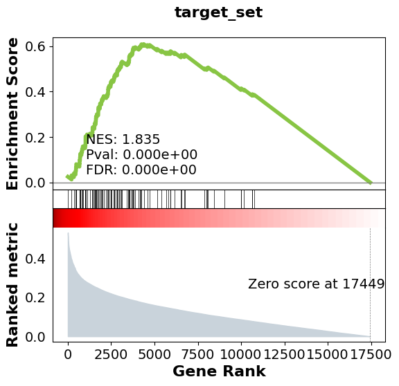

```python
res = gseapy.prerank(
    rnk=spearman_abs_series_tcga,
    gene_sets= {"target_set": top_100_targets},
    processes=4,
    permutation_num=1000,
    seed=42,
    outdir=None,
    verbose=True
)

result_df = res.res2d

print(f"Enrichment Score (ES): {result_df['ES'][0]}")
print(f"Normalized Enrichment Score (NES): {result_df['NES'][0]}")
print(f"Nominal p-value: {result_df['NOM p-val'][0]}")

gseapy.plot.gseaplot(
    rank_metric=spearman_abs_series_tcga,
    term='target_set',
    **res.results['target_set']
);
```

### Top 100 starting from the whole corpus

```python
top_100_all = ['EDA2R', 'FAM54A', 'TTK', 'CENPW', 'FAM83D', 'CEP55', 'MYBL2', 'MELK', 'TRIP13', 'CDCA8',
                'CIRBP', 'CDCA5', 'CDC20', 'UBE2C', 'KIF2C', 'CENPA', 'XPC', 'TPX2', 'C6orf138', 'E2F8', 'C1orf135',
                 'GPSM2', 'STIL', 'CYB5D2', 'RCC1', 'RPS27L', 'CCNB2', 'RFC4', 'DEPDC1', 'BUB1', 'SRD5A1', 'SGOL1',
                  'DSCC1', 'AURKA', 'RAD51AP1', 'PLK1', 'MDM2', 'NCAPH', 'CHEK1', 'DBF4', 'MCM10', 'ACTR3', 'DLGAP5',
                   'HJURP', 'GINS1', 'ORC6L', 'C11orf82', 'RAD54L', 'KIF4A', 'CHEK2', 'SKP2', 'SUV39H2', 'ERCC6L',
                    'DDB2', 'APH1B', 'ACTL6A', 'ANLN', 'TUBA1C', 'DSN1', 'CDK1', 'CCNA2', 'TENC1', 'SNX1', 'ORC1L',
                    'ZNF695', 'CTSL2', 'FAM72B', 'C13orf34', 'CCT5', 'KIF15', 'CKAP2L', 'KIAA1524', 'POLQ', 'MAD2L1',
                     'CDCA7', 'C20orf24', 'MKI67', 'OIP5', 'CENPI', 'CREBL2', 'SKA3', 'FAM72A', 'ZBTB4', 'C17orf108',
                      'TOM1L2', 'CKS1B', 'ECT2', 'NDC80', 'HMMR', 'SRPK1', 'XRCC2', 'NUF2', 'EZH2', 'VAMP2', 'POLR2D',
                       'CDKN3', 'E2F2', 'MTBP', 'FBXO5', 'FAM72D']

# Take just the targets in the set
helper = []
for target in top_100_all:
    if target not in spearman_abs_series_tcga.index:
        helper.append(target)

for h in helper:
    top_100_all.remove(h)
```

```
Enrichment Score (ES): 0.9432853025936598
Normalized Enrichment Score (NES): 2.871088683650704
Nominal p-value: 0.0
```

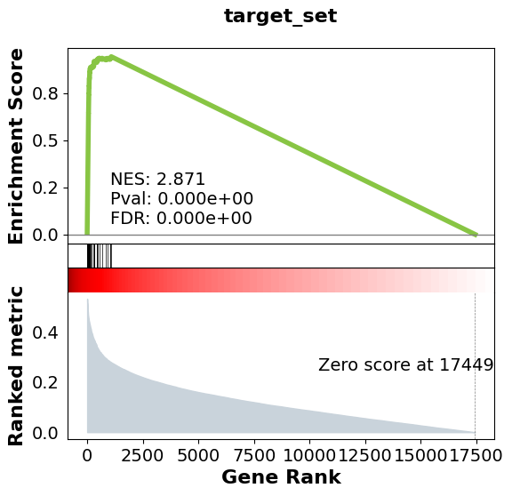

```python
res = gseapy.prerank(
    rnk=spearman_abs_series_tcga,
    gene_sets= {"target_set": top_100_all},
    processes=4,
    permutation_num=1000,
    seed=42,
    outdir=None,
    verbose=True
)

result_df = res.res2d

print(f"Enrichment Score (ES): {result_df['ES'][0]}")
print(f"Normalized Enrichment Score (NES): {result_df['NES'][0]}")
print(f"Nominal p-value: {result_df['NOM p-val'][0]}")

gseapy.plot.gseaplot(
    rank_metric=spearman_abs_series_tcga,
    term='target_set',
    **res.results['target_set']
);
```

## References

[1] Subramanian A, Tamayo P, Mootha VK, Mukherjee S, Ebert BL, Gillette MA, Paulovich A, Pomeroy SL, Golub TR, Lander ES, Mesirov JP. Gene set enrichment analysis: a knowledge-based approach for interpreting genome-wide expression profiles. Proc Natl Acad Sci U S A. 2005 Oct 25;102(43):15545-50. doi: 10.1073/pnas.0506580102. Epub 2005 Sep 30. PMID: 16199517; PMCID: PMC1239896.

[2] Zar, Jerrold. “Significance Testing of the Spearman Rank Correlation Coefficient.” Journal of the American Statistical Association, Informa UK Limited, 1972.

[3] https://tp53.cancer.gov/target_genes